# STAT 432 Final Project: Popular Tweet Classification Analysis

Prepared by Team BKB

Haozhe Wang (hwang270); Ziwei Liu (ziweil2); Jiayi Chen (jchen246) Professor: Ruoqing Zhu

Dec 15, 2018

# Part 1: Introduction and literature review

Recently, people are increasingly using social media to understand the events in the world. This new form of media has changed the way people exchange messages and information. We would like to investigate the Online News Popularity Data Set from UCI Machine Learning Repository (citation#1) to understand what decides the tweets of an online news.

The Online News Popularity Data Set has 39797 rows of data and 61 attributes (58 predicative attributes, 2 non-predictive and 1 goal field), including number of words, number of images and average length of the words in the content.

The target variable is the number of shares of an online news. By performing methods introduced in this course with an emphasis on classification, we hope to gain a broader picture of this data set.

There is a paper (citation #2), **A Proactive Intelligent Decision Support System for Predicting the Popularity of Online News**, written by Kelwin Fernandes, Pedro Vinagre and Paulo Cortez, which studies this data set. Some of the models in this project may have been used in this paper.

# Part 2: Summary Statistics and Data Visualization

```r
pkgs <- c("ggplot2", "plot3D", "glmnet", "MASS", "randomForest", "adabag", "class", "e1071", "ridge")
loaded <- lapply(pkgs, require, character.only = TRUE)
```

## 2.1 Overall Statistics and Graphical Analysis

We first read the data

```r
news = read.csv("OnlineNewsPopularity.csv", header = TRUE)
# remove non-predictive attributes
news = data.frame(news[,c(-1,-2)])
```

Here are some statistics of the dataset:

```r
y = news["shares"]
y = y[,1]
left = range(y)[1]
right = range(y)[2]
cat("The range of the shares is (", left, ",", right, ")","\n")
```

```
## The range of the shares is ( 1 , 843300 )
```

```r
cat("The mean of the shares is", mean(y), "\n")
```

```
## The mean of the shares is 3395.38
```

```r
cat("The median of the shares is", median(y), "\n")
```

```
## The median of the shares is 1400
```

```r
# mode
# from https://stackoverflow.com/questions/2547402/is-there-a-built-in-function-for-
# finding-the-mode
Mode <- function(x) {
  ux <- unique(x)
  ux[which.max(tabulate(match(x, ux)))]
}
cat("The mode of the shares is", Mode(y), "\n")
```

```
## The mode of the shares is 1100
```

We can see that the range of the target variable `shares` is very large, but the mean, median, and mode are more close to its minimum.

## 2.2 Histogram of the data

We plot the histogram of `shares` to have a better understanding of the distribution

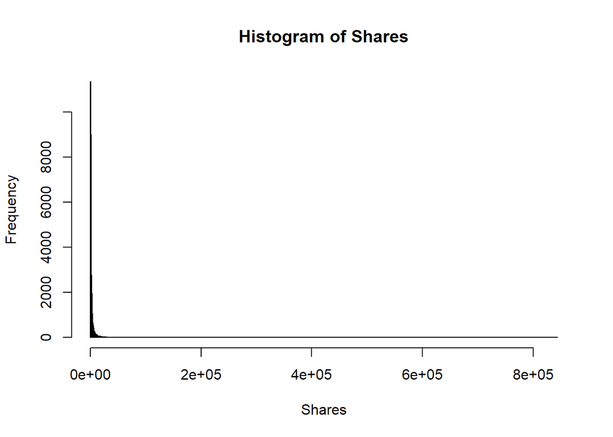

```r
hist(y, breaks=2000, main = "Histogram of Shares", xlab = "Shares")
```

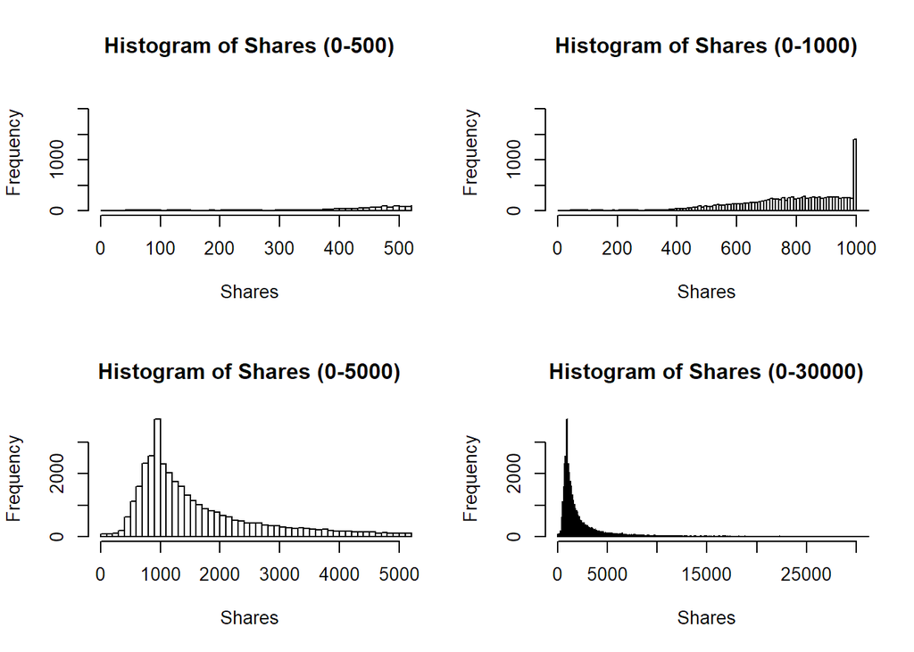

```r
par(mfrow=c(2,2))
hist(y, breaks=100000, main = "Histogram of Shares (0-500)", xlab = "Shares",
     xlim = c(0, 500))
hist(y, breaks=100000, main = "Histogram of Shares (0-1000)", xlab = "Shares",
     xlim = c(0, 1000))
hist(y, breaks=10000, main = "Histogram of Shares (0-5000)", xlab = "Shares",
     xlim = c(0, 5000))
hist(y, breaks=10000, main = "Histogram of Shares (0-30000)", xlab = "Shares",
     xlim = c(0, 30000))
```

From the plots, we can see that most shares are concentrated in the interval $[0, 5000]$.

## 2.3 Principal Component Analysis and Visualization

In order to have a deeper understanding of the distribution and divide the region, we conduct a PCA analysis:

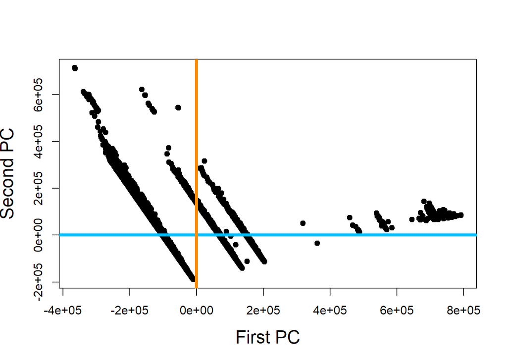

```r
x = news[,1:58]
# Two Principle Components
pcafit <- princomp(x)
pc1 <- matrix(princomp(x)$loadings[,1])
pc2 <- matrix(princomp(x)$loadings[,2])
plot(pcafit$scores[,1], pcafit$scores[,2], xlab = "First PC", ylab = "Second PC", pch = 19, cex.lab = 1.5)
abline(h = 0, col = "deepskyblue", lwd = 4)
abline(v = 0, col = "darkorange", lwd = 4)
```

The variance of the PCs:

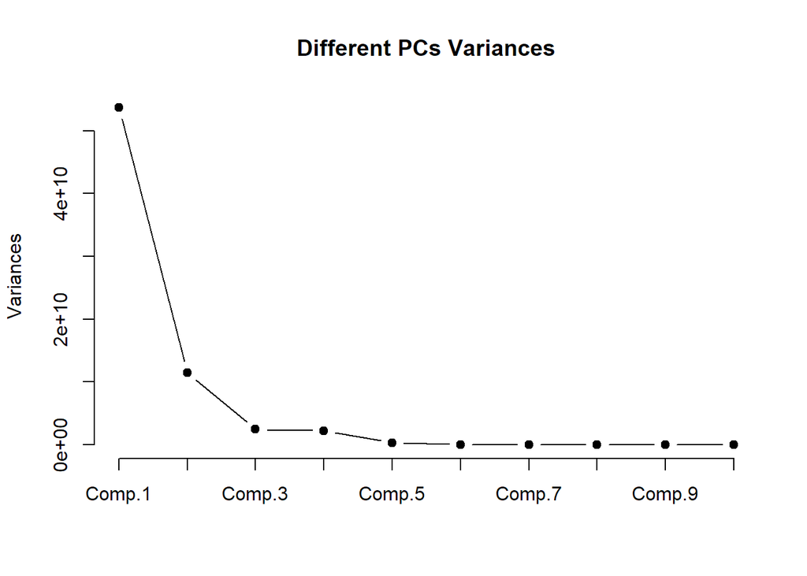

```r
plot(pcafit, type = "l", pch = 19, main = "Different PCs Variances")
```

Clearly, we can see that the data points has certain patterns, and we may conduct regression and classification analysis to investigate these patterns.

3D.

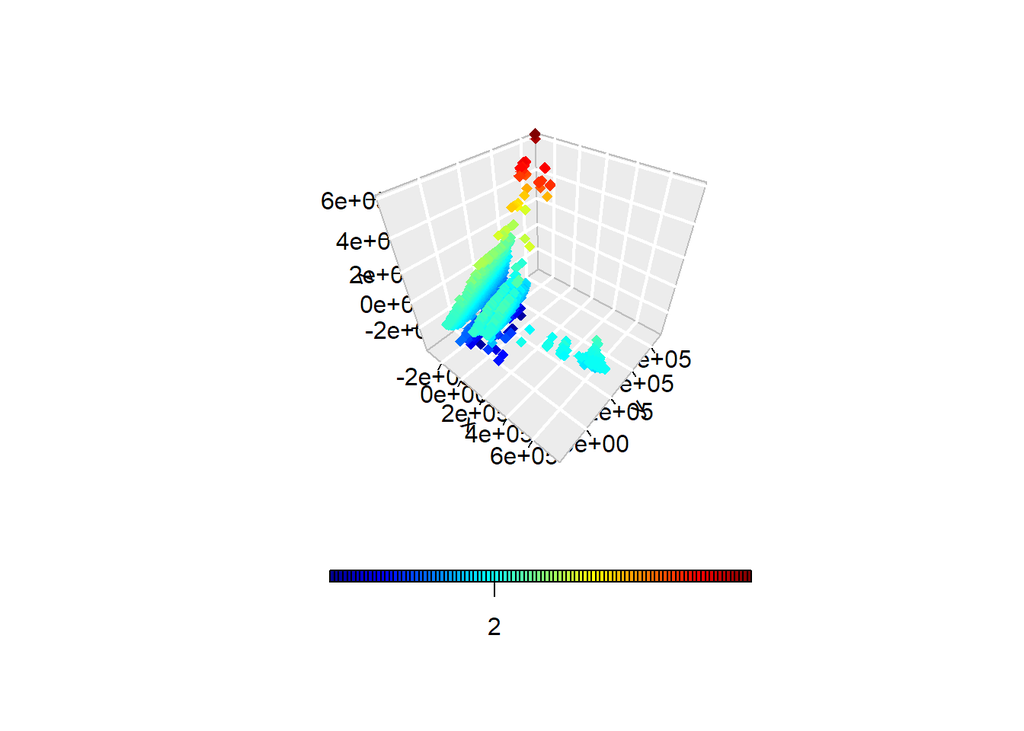

```r
pcs <- prcomp(x)

# 3d visualization
axis = pcs$x
Prin1 = axis[,1]
Prin2 = axis[,2]
Prin3 = axis[,3]
scatter3D(Prin1, Prin2, Prin3, bty = "g", pch = 18,
          pch = 18, ticktype = "detailed",
          colkey = list(at = c(2, 3, 4), side = 1,
          addlines = TRUE, length = 0.5, width = 0.5) )
```

# Part 3: Linear Regression Analysis

```r
lin.fit = lm(shares ~., data=news)
#which(colnames(news) == "weekday_is_sunday")
#which(colnames(news) == "is_weekend")
#which(colnames(news) == "shares")
pvals <- summary(lin.fit)$coef[-1,4]
sig.vars <- colnames(news[,-c(36:37, 59)])[pvals < 0.05]
sig.vars
```

```
##  [1] "n_tokens_title"                "n_tokens_content"
##  [3] "n_unique_tokens"               "num_hrefs"
##  [5] "num_self_hrefs"                "average_token_length"
##  [7] "data_channel_is_lifestyle"     "data_channel_is_entertainment"
##  [9] "data_channel_is_bus"           "kw_min_avg"
## [11] "kw_max_avg"                    "kw_avg_avg"
## [13] "self_reference_min_shares"     "global_subjectivity"
```

With repect to the p-values returned by `lm`, we have successfully screened out insignificant variables and obtained the above list containing variables with high impacts on determining shares in a linear regression.But we do not know how good they are in predicting news popularity since we have not yet examined their collinearity.

```r
lm.ridge(shares ~ .-1, data=news, lambda = 5)
```

```
##                n_tokens_title              n_tokens_content
##                  8.951667e+01                  4.100185e-01
##               n_unique_tokens              n_non_stop_words
##                  1.185590e+03                 -8.266778e+02
##      n_non_stop_unique_tokens                     num_hrefs
##                  5.462350e+01                  2.716129e+01
##                num_self_hrefs                      num_imgs
##                 -5.705502e+01                  1.324072e+01
##                    num_videos          average_token_length
##                  8.167585e+00                 -4.726995e+02
##                  num_keywords     data_channel_is_lifestyle
##                  5.020164e+01                 -1.096374e+03
## data_channel_is_entertainment           data_channel_is_bus
##                 -1.208803e+03                 -8.481120e+02
##        data_channel_is_socmed          data_channel_is_tech
##                 -6.310719e+02                 -5.950078e+02
##         data_channel_is_world                    kw_min_min
##                 -5.396592e+02                  2.229932e+00
##                    kw_max_min                    kw_avg_min
##                  8.538315e-02                 -3.375080e-01
##                    kw_min_max                    kw_max_max
##                 -2.094509e-03                 -5.313441e-04
##                    kw_avg_max                    kw_min_avg
##                 -6.439805e-04                 -3.586494e-01
##                    kw_max_avg                    kw_avg_avg
##                 -1.994698e-01                  1.643376e+00
##     self_reference_min_shares     self_reference_max_shares
##                  2.606553e-02                  5.691218e-03
##    self_reference_avg_sharess             weekday_is_monday
##                 -5.603651e-03                  6.202331e+01
##            weekday_is_tuesday          weekday_is_wednesday
##                 -4.759950e+02                 -3.117634e+02
##           weekday_is_thursday             weekday_is_friday
##                 -4.873051e+02                 -4.492410e+02
##           weekday_is_saturday             weekday_is_sunday
##                  1.903270e+02                 -1.861248e+02
##                    is_weekend                        LDA_00
##                 -8.198706e+00                  1.004306e+02
##                        LDA_01                        LDA_02
##                 -7.117489e+02                 -1.162771e+03
##                        LDA_03                        LDA_04
##                 -2.715198e+02                 -3.354207e+02
##           global_subjectivity     global_sentiment_polarity
##                  2.491818e+03                  6.131886e+02
##    global_rate_positive_words    global_rate_negative_words
##                 -1.228373e+04                  2.614793e+03
##           rate_positive_words           rate_negative_words
##                  1.397422e+03                  1.273599e+03
##         avg_positive_polarity         min_positive_polarity
##                 -1.534275e+03                 -1.654311e+03
##         max_positive_polarity         avg_negative_polarity
##                  2.433752e+02                 -1.692646e+03
##         min_negative_polarity         max_negative_polarity
##                  2.014699e+02                 -3.772858e+02
##            title_subjectivity      title_sentiment_polarity
##                 -9.746216e+01                  2.047048e+02
##        abs_title_subjectivity  abs_title_sentiment_polarity
##                  6.351694e+02                  6.157251e+02
```

We observe that the variance for some of the corresponding $\beta$ are extremely large, hence high collinearity. We then want to further use penalized linear model to see if we can make good predictions.

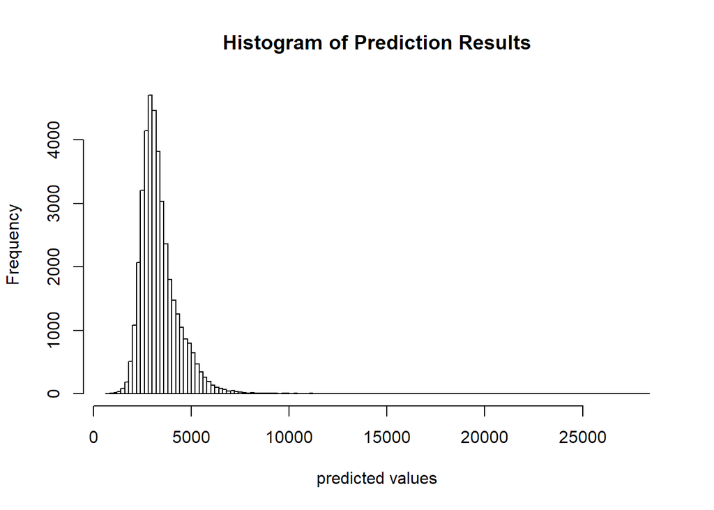

```r
set.seed(432)
index = c()
for(i in 1:length(sig.vars)) {
  index = c(index, which(colnames(news) == sig.vars[i]))
}
rid.fit = cv.glmnet(as.matrix(news[,index]), news$shares,
                    type.measure = "mse", nfolds = 10,
                    alpha = 0)
pred = predict(rid.fit, newx = as.matrix(news[,index]), s = "lambda.min")
hist(pred, breaks=100, main = "Histogram of Prediction Results", xlab = "predicted values")
```

Let’s now see the plot of true shares vs Prediction

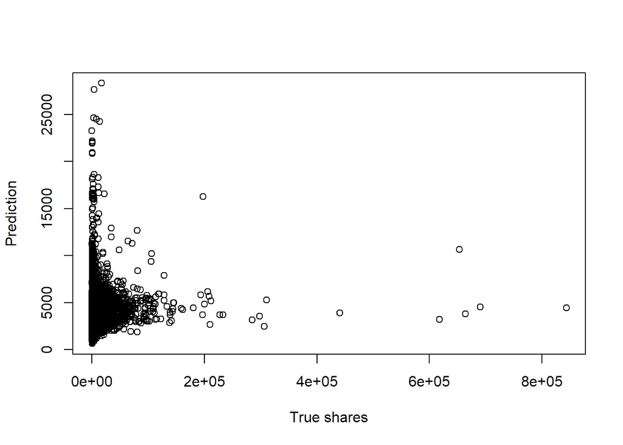

```r
plot(pred ~ news$shares, xlab = "True shares", ylab = "Prediction")
```

The prediction and the true shares seem not to be positive correlated. The points are concentrated at the left corner. Also this is less meaningful to us since we may not want the exact number of shares, but rather we would like to know how popular it is. Therefore, we conclude that linear regression doesn’t befit our overall mission well. But still, we have found some variables that are influential to the news shares.

# Part 4: Variable Selection and Classification

## 4.1 News shares categorization

To reduce the range, we take the logarithm of `shares` and plot the histograms again:

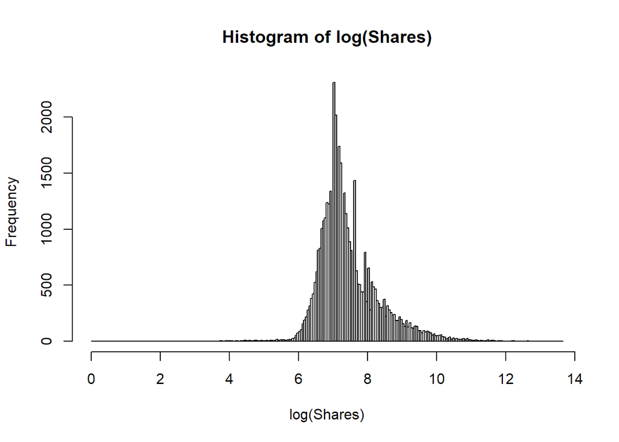

```r
# log
hist(log(news$shares), breaks=200, main = "Histogram of log(Shares)", xlab = "log(Shares)")
```

Now the data are more concentrated to its center.

We then divide `shares` into 3 categories: `low`, `med` and `high` based on the quantile of `log(shares)`:

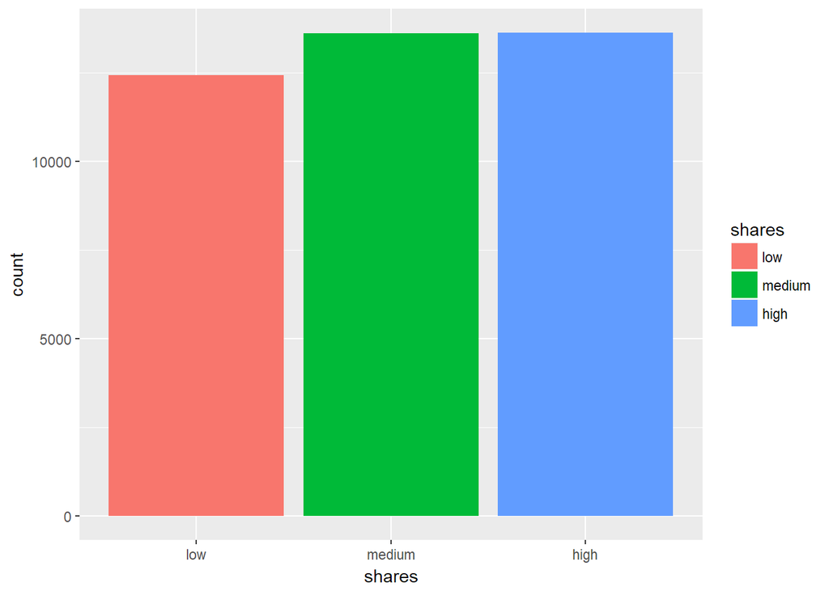

```r
news$shares = log(news$shares)
q = quantile(news$shares, c(1/3, 2/3))

# three classes
news$shares = ifelse(news$shares < q[1], "low",
                ifelse(news$shares >= q[1] & news$shares < q[2], "medium",
                  ifelse(news$shares >=q[2], "high", "NA")))
news$shares = factor(news$shares, levels = c("low","medium","high"))

ggplot(news) +
  aes(x = shares, fill = shares) +
  geom_bar()
```

## 4.2 Train-Test Separation:

Now we do the Train-Test Separation.

```r
# 80% train and 20% test
set.seed(123)
smp_size = floor(0.8 * nrow(news))
train_id = sample(seq_len(smp_size), size = smp_size)
train = data.frame(news[train_id,])
test = data.frame(news[-train_id,])

xtrain = train[,-ncol(train)]
ytrain = train[,ncol(train)]
xtest = test[,-ncol(test)]
ytest = test[,ncol(test)]
```

## 4.3 Random Forest & Boosting

The functions in packages `randomForest` and `adaboost` allow us to fit the random forest model and the boosting model. Each of them has functionality that allows us to find the importance of each variable. We use these functions to help us select significant features.

- Random Forest

```r
forest_model = randomForest(xtrain, ytrain, importance = TRUE)
rf.pred <- predict(forest_model, xtest)
cat("The accuracy of random forest is", mean(rf.pred == ytest), "\n")
```

```
## The accuracy of random forest is 0.4943877
```

```r
print("Confusion matrix")
```

```
## [1] "Confusion matrix"
```

```r
table(rf.pred, ytest)
```

```
##         ytest
## rf.pred   low medium high
##   low    1579    832  419
##   medium  756    979  578
##   high    478    946 1362
```

We can see that the random forest model has around 50% accuracy.

- Boosting & importance

```r
newtrain = train
newtrain$shares = as.factor(newtrain$shares)
pop.adaboost <- boosting(shares ~.,data=newtrain, mfinal=10,
                         control=rpart.control(maxdepth=3))
pop.adaboost.pred <- predict.boosting(pop.adaboost,newdata=test)
cat("The accuracy of boosting is", mean(pop.adaboost.pred$class == ytest), "\n")
```

```
## The accuracy of boosting is 0.4536512
```

```r
print("Confusion matrix")
```

```
## [1] "Confusion matrix"
```

```r
pop.adaboost.pred$confusion
```

```
##                Observed Class
## Predicted Class  low medium high
##          high   1089   1458 1714
##          low    1534    950  456
##          medium  190    349  189
```

We can see that the boosting model has 45% accuracy.

Both of the model perform better than random guess (1/3). Now we extract the most important variables in fitting the models.

```r
# importance
print("Importance from boosting")
```

```
## [1] "Importance from boosting"
```

```r
imp_boost = sort(pop.adaboost$importance, decreasing = TRUE)
imp_boost = imp_boost[imp_boost>0 & !is.na(imp_boost)]
imp_boost[1:min(length(imp_boost), 10)]
```

```
##                 kw_avg_avg                 is_weekend
##                  61.756553                  23.325261
## self_reference_avg_sharess       data_channel_is_tech
##                   6.235941                   5.910911
##     data_channel_is_socmed
##                   2.771333
```

```r
print("Importance from random forest")
```

```
## [1] "Importance from random forest"
```

```r
# mean decrease accuracy
imp = forest_model$importance
imp_forest = sort(imp[, ncol(imp)-1], decreasing = TRUE)
imp_forest = imp_forest[imp_forest>0 & !is.na(imp_forest)]
imp_forest[1:min(length(imp_forest), 10)]
```

```
##                    kw_avg_avg                    kw_max_avg
##                   0.012275625                   0.008337272
##    self_reference_avg_sharess     self_reference_min_shares
##                   0.006537894                   0.005960182
##                    kw_min_avg                    is_weekend
##                   0.004801213                   0.004555507
##     self_reference_max_shares                        LDA_02
##                   0.004342956                   0.004024465
##                        LDA_04 data_channel_is_entertainment
##                   0.003577400                   0.003421206
```

We take their union to be our selected features:

```r
x = names(imp_boost[1:min(length(imp_boost), 10)])
y = names(imp_forest[1:min(length(imp_forest), 10)])
feature_sel = union(x, y)
print(feature_sel)
```

```
##  [1] "kw_avg_avg"                    "is_weekend"
##  [3] "self_reference_avg_sharess"    "data_channel_is_tech"
##  [5] "data_channel_is_socmed"        "kw_max_avg"
##  [7] "self_reference_min_shares"     "kw_min_avg"
##  [9] "self_reference_max_shares"     "LDA_02"
## [11] "LDA_04"                        "data_channel_is_entertainment"
```

# Part 5: Fit classfication

Now we have selected the variables, we fit different classifications models

## 5.1 Logistic Regression

```r
xtrain_sel = xtrain[feature_sel]
xtest_sel = xtest[feature_sel]
# Logistic Regression.
log_fit = cv.glmnet(as.matrix(xtrain_sel), as.matrix(ytrain), family = "multinomial",
                    type.measure = "class",
                    type.multinomial = "grouped",
                    alpha = 0.5, parallel = TRUE)
ypred = predict(log_fit, newx = as.matrix(xtest_sel), s="lambda.min",type = "class")
cat("The accuracy of the logistic regression is", mean(ypred == ytest), "\n")
```

```
## The accuracy of the logistic regression is 0.4821541
```

```r
print("The confusion matrix:")
```

```
## [1] "The confusion matrix:"
```

```r
table(ypred, ytest)
```

```
##         ytest
## ypred     low medium high
##   high    623   1169 1475
##   low    1861   1101  615
##   medium  329    487  269
```

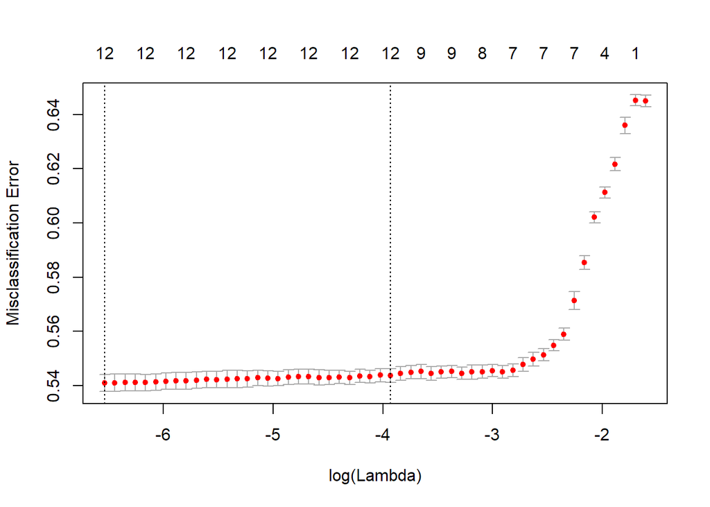

```r
plot(log_fit)
```

## 5.2 K Nearest Neighbors

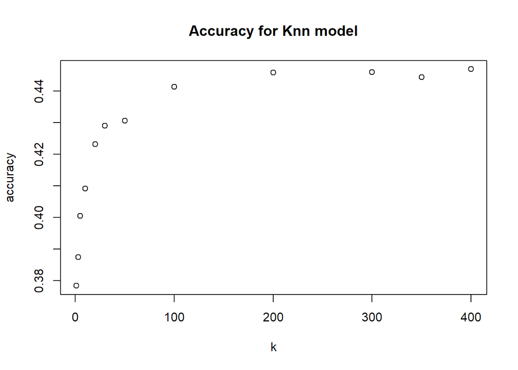

```r
#knn
k = c(1,3,5,10,20,30,50,100,200, 300, 350, 400)
accu = rep(0, length(k))
for(i in 1:length(k)){
  nn = knn(xtrain_sel, xtest_sel, cl = ytrain, k = k[i])
  accu[i] = mean(nn == ytest)
}
plot(k, accu, xlab = "k", ylab = "accuracy", main = "Accuracy for Knn model")
```

```r
k[which.max(accu)]
```

```
## [1] 400
```

We can see that the highest accuracy is reached when k = 400.

```r
# accuracy
cat("The highest accuracy is ", max(accu), "\n")
```

```
## The highest accuracy is  0.4468407
```

## 5.3 Support Vector Machines

```r
svm_model = svm(xtrain_sel, factor(ytrain))
svm_pred = predict(svm_model, data.matrix(xtest_sel))
cat("The accuracy is", mean(svm_pred == ytest), "\n")
```

```
## The accuracy is 0.4911086
```

```r
print("The confusion matrix:")
```

```
## [1] "The confusion matrix:"
```

```r
print(table(svm_pred, ytest))
```

```
##         ytest
## svm_pred  low medium high
##   low    1876   1081  607
##   medium  429    680  414
##   high    508    996 1338
```

# Part 6: Conclusion and discussion

From the analysis above, we saw that the regression method did not perform well on the dataset. The fitted value vs Prediction plot did not show a positive correlation.

We changed our analysis into classification method. After transforming and dividing the target variable `shares` into three categories, we used boosting and random forest to find the most important variables, some of them are `kw_avg_avg`, `is_weekend`, `self_reference_avg_sharess`. Also this method helped to reveal significant variable such as `is_weekend` that regression analysis failed to show.

We then chose these variables and fitted other classification models, including logistic regression, K-Nearest Neighbor and Support Vector Machine. All of them produced accuracy above 0.4, which is better than random guess.

Finally by taking the intersection of variables selected by regression and classification analysis, we have these resulting variables:

```r
intersect(sig.vars, feature_sel)
```

```
## [1] "data_channel_is_entertainment" "kw_min_avg"
## [3] "kw_max_avg"                    "kw_avg_avg"
## [5] "self_reference_min_shares"
```

The Data set gives brief explanations to these features:

1. `data_channel_is_entertainment`: Is data channel ‘Entertainment’?
2. `kw_min_avg`: Avg. keyword (min. shares)
3. `kw_max_avg`: Avg. keyword (max. shares)
4. `kw_avg_avg`: Avg. keyword (avg. shares)
5. `self_reference_min_shares`: Avg. shares of referenced articles in Mashable

Thus we may conclude that, in order to determine the popularity or shares of news, it would benefit to check if the channel is entertainment, the average number of keyword and referenced articles in Mashable.

One of the pitfalls may be how we divided the target variable into classes. We found out that the categorization would have a larger impact on accuracy than classification methods. If we divide data by quantile, the accuracy kept being around 0.4 to 0.5. However if we change the cut-off, say $[0,500]$ is “low”, $[500, 1000]$ is “medium” and $[1000, \infty)$ is “high”, then the accuracy could be a little bit higher (0.6 to 0.7). But that also has apparent flaws, for example less to none classification results will be “low” or “medium”, and the majority will be “high”, hence giving a false positive.

One potential solution is to conduct clustering analysis to observe the outlier and produce more reliable division.

# Part 7: Citation and other works related:

1. https://archive.ics.uci.edu/ml/datasets/online+news+popularity
2. https://pdfs.semanticscholar.org/ad7f/3da7a5d6a1e18cc5a176f18f52687b912fea.pdf

# Part 8: Technical references

1. https://stackoverflow.com/questions/8175912/load-multiple-packages-at-once